# Optimization and Simulation

Uğur Aşkar

# Production Planning

The Bogard Corporation produces three types of bookcases, which it sells to large office supply companies. The production of each bookcase requires two machine operations, trimming and shaping, followed by assembly, which includes inspection and packaging. All three types require 0.4 hours of assebly time, but the machining operations have different processing times, as shown in the following table, in hours per unit:

|  | Standart | Narrow | Wide |
| --- | --- | --- | --- |
| **Trimmer** | 0.2 | 0.4 | 0.6 |
| **Shaper** | 0.6 | 0.2 | 0.5 |

Each machine is available 150 hours per month, and the current size of the assembly department provides capacity of 600 hours. Each bookcase produced yields a unit profit contribution as follows:

|  | Standart | Narrow | Wide |
| --- | --- | --- | --- |
| **Profit** | 8 | 6 | 10 |

```r
lprec = make.lp(0,3)
lp.control(lprec,sense="max")
```

```r
set.objfn(lprec, c(8,6,10))
add.constraint(lprec,c(0.2,0.4,0.6),"<=",150)
add.constraint(lprec,c(0.6,0.2,0.5),"<=",150)
add.constraint(lprec,c(0.4,0.4,0.4),"<=",600)

solve(lprec)
```

[1] 0

```r
cat(paste(c('Objective Value: ',get.objective(lprec))))
```

Objective Value: 3000

```r
cat(paste(c('Variables: ',get.variables(lprec))))
```

Variables: 150 300 0

```r
cat(paste(c('Solution: ',get.dual.solution(lprec))))
```

Solution: 1 10 10 0 0 0 -1

# PL Model

Let’s consider the following situation:

A small business sells two products, named Product 1 and Product 2. Each tonne of Product 1 consumes 30 working hours, and each tonne of Product 2 consumes 20 working hours. The business has a maximum of 2,700 working hours for the period considered. As for machine hours, each tonne of Products 1 and 2 consumes 5 and 10 machine hours, respectively. There are 850 machine hours available.

Each tonne of Product 1 yields 20 Me of profit, while Product 2 yields 60 Me for each tonne sold. For technical reasons, the firm must produce a minimum of 95 tonnes in total between both products. We need to know how many tonnes of Product 1 and 2 must be produced to maximize total profit.

This situation is apt to be modeled as a PL model. First, we need to define the decision variables. In this case we have:

- P1 number of tonnes produced and sold of Product 1
- P2 number of tonnes produced and sold of Product 2

The cost coefficients of these variables are 20 and 60, respectively. Therefore, the objective function is defined multiplying each variable by its corresponding cost coefficient.

The constraints of this LP are:

- A constraint WH making that the total amount of working hours used in Product 1 and Product 2, which equals 30P1 + 20P2, is less or equal than 2,700 hours.
- A similar constraint MH making that the total machine hours 5P1 + 10P2 are less or equal than 850.
- A PM constraint making that the total units produced and sold P1 + P2 are greater or equal than 95.

Putting all this together, and considering that the decision variables are nonnegative, the LP that maximizes profit is:

MAX z = 20P1 + 60P2

s.t.

- WH) 30P1 + 20P2 <= 2700
- MH 5P1 + 10P2 <= 850
- PM) P1 + P2 >= 95
- P1 >= 0, P2 >= 0

```r
#define parameters
obj.fun = c(20,60)
constr = matrix(c(30,20,5,10,1,1), ncol = 2, byrow = TRUE)
constr.dir = c("<=","<=",">=")
rhs = c(2700,850,95)

#solve the problem
prod.sol = lp("max",obj.fun,constr,constr.dir,rhs,compute.sen=TRUE)

#optimal solution
cat(paste(c('Objective Value: ',prod.sol$objval,'\nSolution:',prod.sol$solution,'\nDuals:',prod.sol$duals)))
```

Objective Value: 4900 Solution: 20 75 Duals: 0 8 -20 0 0

# Transportation

Let’s consider a transportation problem of two origins a and b, and three destinations 1, 2 and 3.

In Table below are presented the cost cij of transporting one unit from the origin i to destination j, and the maximal capacity of the origins and the required demand in the destinations.

We need to know how we must cover the demand of the destinations at a minimal cost.

[output not shown]

This situation can be modeled with a LP with the following elements:

- Decision variables of the form xij , representing units transported from origin i to destination j
- An objective function with cost coefficients equal to cij
- Two sets of constraints: a less or equal set of constraints for each origin, limiting the units to be transported, and a greater of equal set of constraints representing that the demand of each destination must be covered.

The resulting LP is:

MIN z = 8xa1 + 6xa2 + 3xa3 + 2xb1 + 4xb2 + 9xb3

s.a.

```r
lprec = make.lp(0,6)
lp.control(lprec,sense="min")
```

```r
set.objfn(lprec, c(8,6,3,2,4,9))
add.constraint(lprec,c(1,1,1,0,0,0),"<=",70)
add.constraint(lprec,c(0,0,0,1,1,1),"<=",40)
add.constraint(lprec,c(1,0,0,1,0,0),">=",40)
add.constraint(lprec,c(0,1,0,0,1,0),">=",35)
add.constraint(lprec,c(0,0,1,0,0,1),">=",20)

solve(lprec)
```

[1] 0

```r
cat(paste(c('Objective Value: ',get.objective(lprec))))
```

Objective Value: 350

```r
cat(paste(c('Variables: ',get.variables(lprec))))
```

Variables: 0 35 20 40 0 0

```r
cat(paste(c('Solution: ',get.dual.solution(lprec))))
```

Solution: 1 0 -2 4 6 3 4 0 0 0 0 8

# Coordinating Production and Marketing

The Andrews Apple Products Company purchases apples from local growers and makes applesauce and apple juice. It costs $0.80 to product a jar of applesauce and $0.60 to produce a bottle of apple juice. The company has a policy that at least 20% but no more than 60% of its output must be applesauce.

The company wants to meet but not exceed the demand for each product. The marketing manager estimates that the demand for applesauce is a maximum of 5,000 jars, plus an additional 3 jars for each $1 spent on advertising for applesauce. The maximum demand for apple juice is estimated to be 4,000 bottles, plus and additional 5 bottles for every $1 spent on advertising for apple juice. The company has $16,000 to spend on producing and advertising its two products. Applesauce sells for $1.75 per jar; apple juice sells for $1.75 per bottle. The company wants to know how many units of each product to produce, and how much advertising to spend on each product, in order to maximize profit.

```r
lprec = make.lp(0,4)
lp.control(lprec,sense="max")
```

```r
set.objfn(lprec, c(0.95,1.15,-1,-1))
add.constraint(lprec,c(0.8,-0.2,0,0),">=",0)
add.constraint(lprec,c(0.4,-0.6,0,0),"<=",0)
add.constraint(lprec,c(1,-3,0,0),"<=",5000)
add.constraint(lprec,c(0,1,0,-5),"<=",4000)
add.constraint(lprec,c(0.8,0.6,1,1),"<=",16000)

solve(lprec)
```

[1] 0

```r
cat(paste(c('Objective Value: ',get.objective(lprec))))
```

Objective Value: 20750

```r
cat(paste(c('Variables: ',get.variables(lprec))))
```

Variables: 4200 16800 0 2560

```r
cat(paste(c('Solution: ',get.dual.solution(lprec))))
```

Solution: 1 0 0 0 0.4375 1.1875 0 0 -2.1875 0

# Make or Buy

A sudden increase in the demand for smoke detectors has left Acme Alarms with insufficient capacity to meet demand. The company has seen monthly demand from its retailers for its electronic and battery-operated detectors rise to 20,000 and 10,000, respectively. Acme’s production process involves three departments: fabrication, assembly, and shipping. The relevant quantitative data on production and prices are summarized as follows:

| Department | Monthly Hours Available | Hours/Unit (Electronic) | Hours/Unit (Battery) |
| --- | --- | --- | --- |
| **Fabrication** | 2000 | 0.15 | 0.10 |
| **Assembly** | 4200 | 0.20 | 0.20 |
| **Shipping** | 2500 | 0.10 | 0.15 |
| Variable Cost/Unit |  | 18.80 | 16.00 |
| Retail Price |  | 29.50 | 28.00 |

The company also has the option to obtain additional units from a subcontractor, who has offered to supply up to 20,000 units per month in any combination of electric and battery-operated models, at a charge of $21.50 per unit. For this price, the subcontractor will test and ship its models directly to the retailers without using Acme’s production process

```r
lprec = make.lp(0,4)
lp.control(lprec,sense="max")
```

```r
set.objfn(lprec, c(10.7,12,8,6.5))
add.constraint(lprec,c(1,0,1,0),"<=",20000)
add.constraint(lprec,c(0,1,0,1),"<=",10000)
add.constraint(lprec,c(0.15,0.1,0,0),"<=",2000)
add.constraint(lprec,c(0.2,0.2,0,0),"<=",4200)
add.constraint(lprec,c(0.1,0.15,0,0),"<=",2500)
add.constraint(lprec,c(0,0,1,1),"<=",20000)

solve(lprec)
```

[1] 0

```r
cat(paste(c('Objective Value: ',get.objective(lprec))))
```

Objective Value: 298000

```r
cat(paste(c('Variables: ',get.variables(lprec))))
```

Variables: 6666.66666666667 10000 13333.3333333333 0

```r
cat(paste(c('Solution: ',get.dual.solution(lprec))))
```

Solution: 1 8 10.2 18 0 0 0 0 0 0 -3.7

# Coffee Blending and Sales

Hill-O-Beans Coffee Company blends four component beans into three final blends of coffee:

One is sold to luxury hotels, another to restaurants, and the third to supermarkets for store label brands.

The company has four reliable bean supplies:

Robusta, Javan Arabica, Liberica, and Brazilian Arabica.

The following table summarizes the very precise recipes for the final coffee blends, the cost and availability information for the four components, and the wholesale price per pound of the final blends. The percentages indicate the fraction of each component to be used in each blend.

| Component | Hotel | Restaurant | Market | Cost per Pound | Max Weekly Availability (lbs) |
| --- | --- | --- | --- | --- | --- |
| **Robusta** | 20% | 35% | 10% | $0.60 | 40,000 |
| **Javan Arabica** | 40% | 15% | 35% | $0.80 | 25,000 |
| **Liberica** | 15% | 20% | 40% | $0.55 | 20,000 |
| **Brazilian Arabica** | 25% | 30% | 15% | $0.70 | 45,000 |
| Wholesale Price Per Pound | $1.25 | $1.50 | $1.40 |  |  |

```r
lprec = make.lp(0,3)
lp.control(lprec,sense="max")
```

```r
set.objfn(lprec, c(0.5525,0.85,0.735))
add.constraint(lprec,c(0.2,0.35,0.1),"<=",40000)
add.constraint(lprec,c(0.4,0.15,0.35),"<=",25000)
add.constraint(lprec,c(0.15,0.2,0.4),"<=",20000)
add.constraint(lprec,c(0.25,0.3,0.15),"<=",45000)
add.constraint(lprec,c(1,1,1),"<=",100000)
add.constraint(lprec,c(1,0,0),"<=",10000)
add.constraint(lprec,c(0,1,0),"<=",25000)
add.constraint(lprec,c(0,0,1),"<=",30000)

solve(lprec)
```

[1] 0

```r
cat(paste(c('Objective Value: ',get.objective(lprec))))
```

Objective Value: 48825

```r
cat(paste(c('Variables: ',get.variables(lprec))))
```

Variables: 10000 25000 30000

```r
cat(paste(c('Solution: ',get.dual.solution(lprec))))
```

Solution: 1 0 0 0 0 0 0.5525 0.85 0.735 0 0 0

# Post Office

```r
lprec <- make.lp(0,14)
lp.control(lprec, sense="min")
```

```r
set.objfn(lprec, c(120,120,120,120,120,120,120,40,40,40,40,40,40,40))
add.constraint(lprec, c(8,0,0,8,8,8,8,4,0,0,4,4,4,4), ">=", 136)
add.constraint(lprec, c(8,8,0,0,8,8,8,4,4,0,0,4,4,4), ">=", 104)
add.constraint(lprec, c(8,8,8,0,0,8,8,4,4,4,0,0,4,4), ">=", 120)
add.constraint(lprec, c(8,8,8,8,0,0,8,4,4,4,4,0,0,4), ">=", 152)
add.constraint(lprec, c(8,8,8,8,8,0,0,4,4,4,4,4,0,0), ">=", 112)
add.constraint(lprec, c(0,8,8,8,8,8,0,0,4,4,4,4,4,0), ">=", 128)
add.constraint(lprec, c(0,0,8,8,8,8,8,0,0,4,4,4,4,4), ">=", 88)
add.constraint(lprec, c(1,1,1,1,1,1,1,-3,-3,-3,-3,-3,-3,-3), ">=", 0)

solve(lprec)
```

[1] 0

```r
cat(paste(c('Objective Value: ',get.objective(lprec))))
```

Objective Value: 2552.38095238095

```r
cat(paste(c('Variables: ',get.variables(lprec))))
```

Variables: 6.33333333333333 5 0.333333333333333 4.14285714285714 0 3.33333333333333 0 0 0 0 6.38095238095238 0 0 0

```r
cat(paste(c('Solution: ',get.dual.solution(lprec))))
```

Solution: 1 4.76190476190476 0 4.76190476190476 4.76190476190476 0 4.76190476190476 0 5.71428571428572 0 0 0 0 38.0952380952381 0 0 0 0 0 0 19.047619047619 0 0

# Cargo

```r
lprec <- make.lp(0,12)
lp.control(lprec, sense="max")
```

```r
set.objfn(lprec, c(2000,2500,5000,3500,2000,2500,5000,3500,2000,2500,5000,3500))
add.constraint(lprec, c(400,300,200,500,0,0,0,0,0,0,0,0), "<=", 5000)
add.constraint(lprec, c(0,0,0,0,400,300,200,500,0,0,0,0), "<=", 4000)
add.constraint(lprec, c(0,0,0,0,0,0,0,0,400,300,200,500), "<=", 8000)
add.constraint(lprec, c(1,1,1,1,0,0,0,0,0,0,0,0), "<=", 10)
add.constraint(lprec, c(0,0,0,0,1,1,1,1,0,0,0,0), "<=", 8)
add.constraint(lprec, c(0,0,0,0,0,0,0,0,1,1,1,1), "<=", 12)
add.constraint(lprec, c(1,0,0,0,1,0,0,0,1,0,0,0), "<=", 18)
add.constraint(lprec, c(0,1,0,0,0,1,0,0,0,1,0,0), "<=", 10)
add.constraint(lprec, c(0,0,1,0,0,0,1,0,0,0,1,0), "<=", 5)
add.constraint(lprec, c(0,0,0,1,0,0,0,1,0,0,0,1), "<=", 20)

solve(lprec)
```

[1] 0

```r
cat(paste(c('Objective Value: ',get.objective(lprec))))
```

Objective Value: 107500

```r
cat(paste(c('Variables: ',get.variables(lprec))))
```

Variables: 0 5 5 0 0 0 0 8 0 0 0 12

```r
cat(paste(c('Solution: ',get.dual.solution(lprec))))
```

Solution: 1 0 0 0 2500 2500 2500 0 0 2500 1000 -500 0 0 0 -500 0 0 0 -500 0 0 0

# Selecting Projects

Following are the resource requirements and the estimated profit for each project:

| Project | Expense ($000) | Scientists Required | Profit ($000) |
| --- | --- | --- | --- |
| **1** | 60 | 7 | 36 |
| **2** | 110 | 9 | 82 |
| **3** | 53 | 8 | 29 |
| **4** | 147 | 4 | 16 |
| **5** | 192 | 7 | 56 |
| **6** | 185 | 6 | 61 |
| **7** | 173 | 8 | 48 |
| **8** | 165 | 5 | 41 |

```r
library(lpSolveAPI)
DataForModel <- read.table(
  "Week5_Q11_1.csv",
  sep=",", header=TRUE)

NoOfConstraints <- ncol(DataForModel)-2
NoOfVariables <-nrow(DataForModel)-1

# We create a new empty model with NoOfConstraints rows and NoOfVariables columns
lpModel <-make.lp(NoOfConstraints,NoOfVariables)

#Name the model variables
VariableNames <- t(DataForModel[1:NoOfVariables,1])
#Name the constraints
ConstraintNames <- colnames(DataForModel[3:(NoOfConstraints+2)])

# maximize the profit
lp.control(lpModel, sense="max")
```

```r
# Setting all variable types to be binary
for(i in 1:NoOfVariables){
  set.type(lpModel,i,"binary")
}

# Setting the appropriate data for each project, that translates to a column in the lpSolve equation
for(i in 1:NoOfVariables){
  set.column(lpModel, i, DataForModel[i,3:(NoOfConstraints+2)])
}
# Each constraint provides the upper bound of rhs
#set.constr.type(lpmodel,rep("<=", NoOfConstraints)) -> Use this if all your constraints are of the same inequality type
set.constr.type(lpModel, c("<=", "<=", "<=", ">="))

# Set the RHS values
set.rhs(lpModel, DataForModel[(NoOfVariables+1),3:(NoOfConstraints+2)])

#Check the model
dimnames(lpModel) <- list(ConstraintNames, VariableNames)

#Objective
obj.profit <- DataForModel[1:NoOfVariables,2]
set.objfn(lpModel, obj.profit)

#Check the model
#lpModel

# In order to be able to visually check the model, you can write the model to a text file
write.lp(lpModel,'modelQ11_1.lp',type='lp')

solve(lpModel)
```

[1] 0

```r
cat(paste(c('Objective Value: ',get.objective(lpModel))))
```

Objective Value: 191

```r
cat(paste(c('Variables: ',get.variables(lpModel))))
```

Variables: 0 1 0 0 0 1 1 0

```r
cat(paste(c('Solution: ',get.dual.solution(lpModel))))
```

Solution: 1 0 0 56 0 36 26 29 16 0 61 48 41

# Warehouse

A company is considering opening warehouses in four cities New York, Los Angeles, Chicago, and Atlanta. Each warehouse can ship 100 units per week. The weekly fixed cost of keeping each warehouse open is $400 for New York, $500 for Los Angeles, $300 for Chicago, and $150 for Atlanta. Region 1 of the country requires 80 units per week, region 2 requires 70 units per week, and region 3 requires 40 units per week. The costs(including production and shipping costs) of sending one unit from a plant to a region are show in Table below. We want to meet weekly demands at minimum costs, subject to the preceding information and the following restrictions:

- If the New York warehouse is opened, the the Los Angeles warehouse must be opened.
- At most two warehouses can be opened
- Either the Atlanta or the Los Angeles warehouse must be opened.

| From | Region 1 | Region 2 | Region 3 | Capacity | fi |
| --- | --- | --- | --- | --- | --- |
| **New York** | 20 | 40 | 50 | 100 | 400 |
| **Los Angeles** | 48 | 15 | 26 | 100 | 500 |
| **Chicago** | 26 | 35 | 18 | 100 | 300 |
| **Atlanta** | 24 | 50 | 35 | 100 | 150 |
| Demand | 80 | 70 | 40 |  |  |

```r
library(lpSolveAPI)
DataForModel <- read.table(
  "Week5_ICA_Q1.csv",
  sep=";", header=TRUE)

NoOfConstraints <- ncol(DataForModel)-2
NoOfVariables <-nrow(DataForModel)-1

# We create a new empty model with NoOfConstraints rows and NoOfVariables columns
lpModel <-make.lp(NoOfConstraints,NoOfVariables)

#Name the model variables
VariableNames <- t(DataForModel[1:NoOfVariables,1])
#Name the constraints
ConstraintNames <- colnames(DataForModel[3:(NoOfConstraints+2)])

# maximize the profit
lp.control(lpModel, sense="min")
```

```r
# Setting all variable types to be binary
for(i in 1:4){
  set.type(lpModel,i,"binary")
}

# Setting the appropriate data for each project, that translates to a column in the lpSolve equation
for(i in 1:NoOfVariables){
  set.column(lpModel, i, DataForModel[i,3:(NoOfConstraints+2)])
}
# Each constraint provides the upper bound of rhs
#set.constr.type(lpmodel,rep("<=", NoOfConstraints)) -> Use this if all your constraints are of the same inequality type
set.constr.type(lpModel, c(">=", ">=", ">=", "<=", "<=", "<=", "<=", "<=", "<=", ">="))

# Set the RHS values
set.rhs(lpModel, DataForModel[(NoOfVariables+1),3:(NoOfConstraints+2)])

#Check the model
dimnames(lpModel) <- list(ConstraintNames, VariableNames)

#Objective
obj.profit <- DataForModel[1:NoOfVariables,2]
set.objfn(lpModel, obj.profit)

#Check the model
#lpModel
# In order to be able to visually check the model, you can write the model to a text file
write.lp(lpModel,'modelICA_Q1.lp',type='lp')

solve(lpModel)
```

[1] 0

```r
cat(paste(c('Objective Value: ',get.objective(lpModel))))
```

Objective Value: 4750

```r
cat(paste(c('Variables: ',get.variables(lpModel))))
```

Variables: 0 1 0 1 0 0 0 0 70 30 0 0 0 80 0 10

```r
cat(paste(c('Solution: ',get.dual.solution(lpModel))))
```

Solution: 1 24 24 35 -4 -9 -17 0 0 0 0 0 -400 -1400 150 0 20 19 33 0 0 19 28 0 0 26 0

# Research and Development Planning Simulation

A firm is in the process of assessing the economic prospects for a new bottling machine it is developing. Future research and development expenses could range from $4 to $9 million, with a most likely value around $7 million. The life of the product will be anywhere from 3 to 10 years. Yearly unit sales will range from 100 to 500, with a most likely value around 300. The machines will sell for between $20,000 and $25,000 each. The production cost of the machine is expected to be $13,000 but could be as low as $11,000 or as high as $15,000. The firm’s discount rate is 10%.

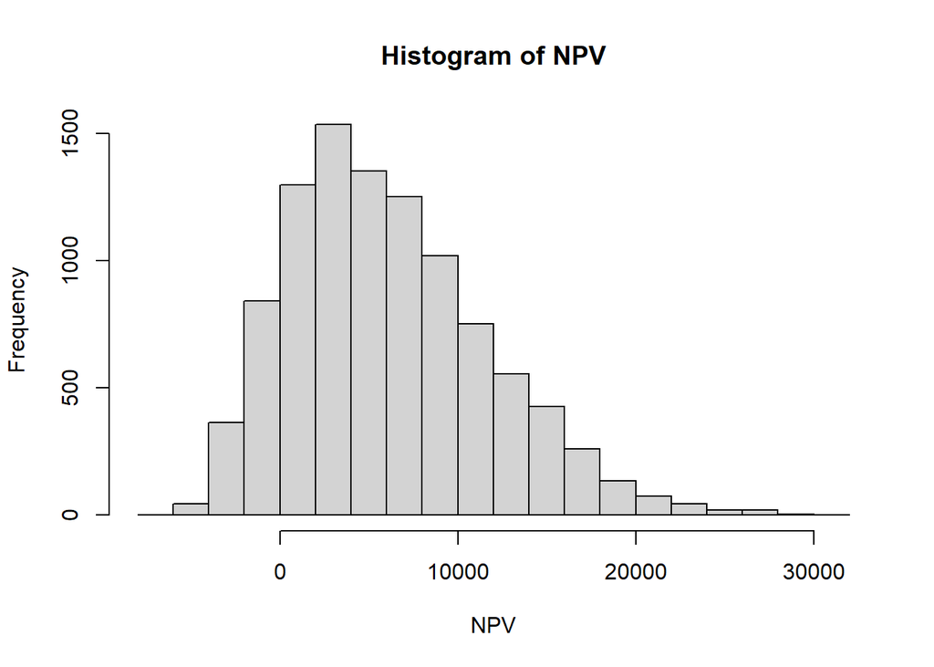

```r
NPV = NULL

for(j in 1:10000) {
#Variables
RDCost = rtriangle(n=1, 4000, 9000, 7000)
ProdCost = rtriangle(n=1, 11, 15, 13)
Price = runif(n=1, min=20, max=25)
Sales = rtriangle(n=1, 100, 500, 300)
Life = sample(3:10, 1)
# Life = sample(x = c(3, 4, 5, 6, 7, 8, 9, 10), size=1, prob=(1/8, 1/8, 1/8, 1/8, 1/8, 1/8, 1/8, 1/8), replace=T)
DiscountRate = 0.1
DiscountedValue = RDCost * (-1)
NPV_sub = 0


for(i in 1:Life) {
  DiscountedValue = DiscountedValue + ((Price - ProdCost) * Sales) / ((1 + DiscountRate)**i)
  NPV_sub = NPV_sub + DiscountedValue
  DiscountedValue = 0

}

NPV[j] = NPV_sub

}

hist(NPV)
```

```r
kable(as.array(summary(NPV)))
```

| Var1 | Freq |
| --- | --- |
| Min. | -6079.292 |
| 1st Qu. | 1936.464 |
| Median | 5358.469 |
| Mean | 6108.031 |
| 3rd Qu. | 9528.035 |
| Max. | 30014.618 |

# Final

```r
lprec = make.lp(0,3)
lp.control(lprec,sense="max")
```

```r
set.objfn(lprec, c(30,50,80))
add.constraint(lprec,c(1,1,1),">=",500)
add.constraint(lprec,c(-1,1,1),"<=",-50)
add.constraint(lprec,c(2,1,2),"<=",1500)
add.constraint(lprec,c(3,4,2),"<=",2800)
add.constraint(lprec,c(2,3,3),"<=",1200)

solve(lprec)
```

[1] 0

```r
cat(paste(c('Objective Value: ',get.objective(lprec))))
```

Objective Value: 25000

```r
cat(paste(c('Variables: ',get.variables(lprec))))
```

Variables: 300 0 200

```r
cat(paste(c('Solution: ',get.dual.solution(lprec))))
```

Solution: 1 -70 0 0 0 50 0 -30 0